# Análisis Estadístico de Tickets de Mercadona

David Ricci, Hugo Frasquet, Juan Gómez, Mateo Méndez, Pablo Quesada, Sebastian David

14 de mayo, 2024

# 1 INTRODUCCIÓN

La era del big data ha marcado un punto de inflexión en la forma en que las empresas comprenden sus operaciones, mercados y consumidores. En este contexto se sitúa nuestro proyecto, ProyectoTD2024 del Grupo M, que se ha dedicado al estudio detallado de los tickets de compra de Mercadona, uno de los supermercados más renombrados en España. A fecha de hoy, el repositorio permanece en privado por motivos de confidencialidad. Si en un futuro se decide hacer público, se podrá acceder a través del siguiente enlace: ProyectoTD2024.

[figure not shown]

Inicio de ticket en formato PDF

[figure not shown]

Final de ticket en formato PDF

# 2 GESTIÓN DE DATOS

La primera parte del proyecto se ha basado en la obtención de tickets de Mercadona. Para ello, hemos preguntado a personas que conocemos si tenían tickets de compra de Mercadona y si podían proporcionárnoslos. Nuestro profesor de Tratamiento de Datos nos proporcionó un script en Python que nos permitía transformar los tickets en formato PDF a formato TXT. Hemos creado un programa que extrae todos los tickets en formato de texto de la carpeta donde se almacenan y los organiza, reescribiendo los datos depurados en otros documentos de texto que más tarde se utilizarán para analizar los datos.

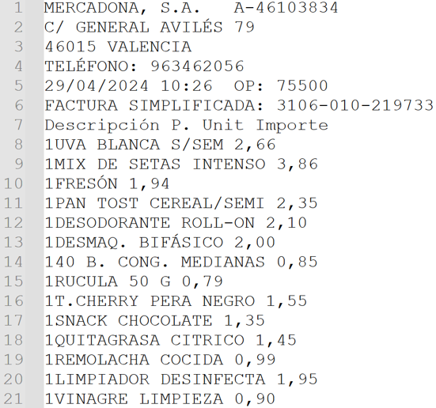

Ticket no estructurado

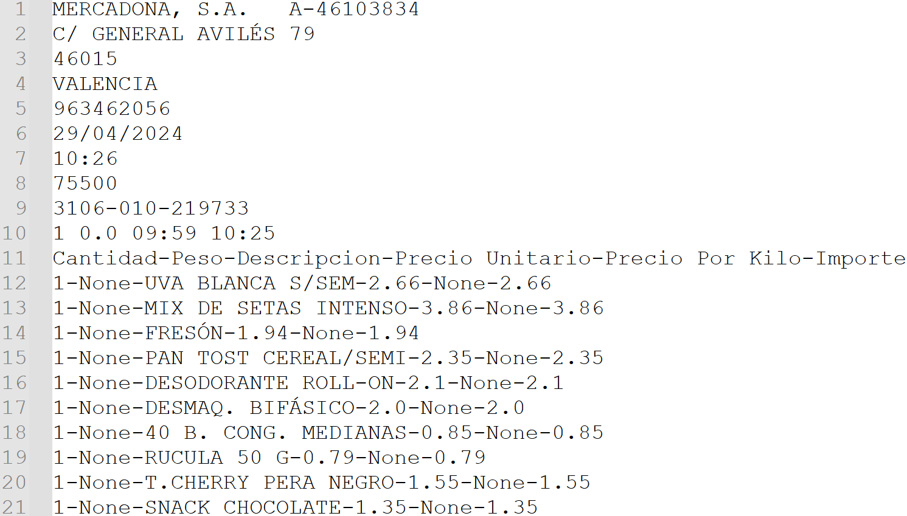

Ticket estructurado

Los problemas más grandes a los que nos hemos tenido que enfrentar es al manejo de casos donde los productos mostraban su información en kilos, precios unitarios y la existencia de parking.

Productos a kilo

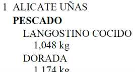

Pescados

[figure not shown]

Precios unitarios

# 3 IMPORTACIÓN DE LOS DATOS

Una vez estructurados y limpiados los datos decidimos que era hora de importarlos en R. Entre muchas librerías, nos hemos decantado por usar ‘tidyverse’, ya que nos permite trabajar con los ficheros y los datos de una manera familiar a la vista en clases. Decidimos que lo mejor sería utilizar ‘R’ para hacer nuestro análisis de los datos, ya que es un lenguaje de programación muy potente y versátil que nos permite realizar análisis estadísiticos de una manera muy eficiente. Esto se debe a que, la importación no depende de que tipo de análisis se vaya a realizar, por lo que es mejor tenerlo todo en un único archivo y que todos los miembros del grupo puedan acceder a él sin modificar los datos. ‘Fecha de Compra’ es un objeto de tipo fecha, ‘Hora de Operación’ es un objeto de tipo hora, al igual que ‘Hora de Entrada’ y ‘Hora de Salida’.

# 4 VARIABLES USADAS EN EL ANÁLISIS

Descripción de las Variables del ProyectoTD2024

[output not shown]

# 5 ANÁLISIS DE DATOS

Una vez que teníamos todos los tickets consolidados en un único dataframe, procedimos a realizar un análisis exploratorio de los datos. Para ello, recurrimos al uso de gráficas como el boxplot y el histograma, que nos permitieron identificar valores atípicos y distribuciones inusuales. Posteriormente, realizamos un análisis de correlación entre las variables, lo que nos permitió identificar posibles relaciones entre ellas.

Después de visualizar y comprender mejor las variables, nos reunimos para decidir que preguntas podemos responder, y nos decantamos por las siguientes: - ¿Cómo afecta el estacionamiento en las compras? - ¿Cómo afecta la ubicación del local a la compra? - ¿Existen patrones de compra según la hora del día? - ¿Cómo varía la compra entre distintos días?

A continuación, se presentan los análisis realizados para responder a las preguntas planteadas.

## 5.1 ¿Cómo afecta el estacionamiento en las compras?

Uno de los aspectos a considerar que puede tener un Supermercado como Mercadona es cómo influye el uso del parking en las compras de sus clientes. Para ello, hemos hecho un análsis de la duración de los tickets en el parking y el importe total de la compra.

Primero de todo, queríamos ver como influía el tiempo del parking en el importe total de la compra. Para ello, hemos realizado un gráfico de dispersión con una línea de tendencia que nos muestra la relación entre ambas variables.

[interactive chart not shown]

Como podemos observar en el gráfico, parece haber una tendencia positiva entre el tiempo de parking y el importe total de la compra. Aunque tenemos algunas compras que, aun teniendo un tiempo de parking alto, el importe no es alto. Para profundizar en este análisis, hemos realizado un histograma de la duración en el parking para ver la distribución de los tiempos de parking.

[interactive chart not shown]

El histograma sugiere que los clientes de Mercadona que utilizan el parking lo hacen más para compras de corta duración que para compras de larga duración.

## 5.2 ¿Cómo afecta la ubicación del local a la compra?

Lo primordial fue calcular las coordenadas de cada local de Mercadona. Después exportamos de [OpenStreetMap](https://www.openstreetmap.org/) un fichero que contenía las coordenadas de los SuperMercados más cercanos a cada local de Mercadona que tenemos en nuestros datos.

Calculamos la distancia euclidiana entre cada sucursal y sus competidores más próximos, definiendo dos rangos de proximidad: 500 metros y 1 kilómetro. Para ver si teníamos alguna correlación entre la distancia a los competidores y el importe total de la compra, decidimos utilizar pearson para ver si había alguna correlación entre ambas variables, y representarla en un gráfico de dispersión. Cuando vimos el potencial que tiene hacer un análisis de correlación de Pearson, decidimos preguntarnos si existe alguna correlación entre la distancia a los competidores y el número de compras.

[interactive chart not shown]

En conclusión, aunque inicialmente podríamos haber esperado que la competencia cercana tuviera un impacto significativo en las compras en diferentes ubicaciones, nuestros análisis no respaldan esta hipótesis.

También podemos comprobar que aún siendo la correlación entre el número de competidores y el número de tickets mejor que la correlación entre el número de competidores y el importe total de la compra, no podemos decir que haya una correlación significativa entre ambas variables.

Ahora, le hemos dado un cambio de enfoque a nuestro análisis para ver la tendencia de la compra dependiendo de la Municipio. Para ello, hemos cogido la variable ‘Municipio’ como la principal. Queríamos ver cuál era la relación entre la Municipio y el importe total de la compra.

[interactive chart not shown]

El gráfico sugiere que, aunque Denia se destaque como el lugar donde se realizan las compras de mayor valor, Valencia también muestra compras significativamente elevadas y cercanas a ese máximo. Esta observación sugiere que Valencia podría tener un nivel económico similar o incluso superior al de Denia, a pesar de que Denia tenga la compra más alta en este conjunto de datos limitado.

[interactive chart not shown]

Al analizar el gráfico, podemos verificar si efectivamente donde se compran los productos más caros coincide con las regiones donde el importe total es más alto. Observamos que, si bien Denia destaca como el lugar donde se adquiere el producto más costoso, la ciudad de Valencia lidera en cuanto al promedio de precios y volumen de compras.

## 5.3 ¿Existen patrones de compra según la hora del día?

Una de las preguntas que más nos interesaba responder y analizar era como influye la compra en función de la hora del día.

Queríamos saber a qué horas va más la gente a comprar. Para ello, hemos realizado un histograma que nos muestra la distribución de las compras a lo largo del día.

También estábamos interesados en saberr si hay alguna relación entre la hora de compra y el importe total del ticket. Para ello, hemos realizado un boxplot que nos muestra la relación entre la hora de compra y el importe total del ticket.

[interactive chart not shown]

Como se puede ver en el histograma, la mayoría de las compras se realizan a las ocho de la tarde. Es también curioso observar como a primera y última hora del día apenas hay clientes.

[interactive chart not shown]

El gráfico sugiere que el importe total del ticket varía significativamente en función de la hora del día. En particular, parece que los tickets de compra realizados entre las 13:00 y las 16:00 horas tienden a tener un importe total más bajo pero con más valores atípicos.

Por otro lado, los tickets de compra realizados entre las 09:00 y las 13:00 horas tienden a tener un importe total más alto, con menos valores atípicos.

Como curiosidad, podemos ver que la compra con el importe más alto se realizó entre las 11:00 y las 12:00 de la mañana, con un valor de casi 250 euros.

## 5.4 ¿Cómo varía las compras entre distintos días?

Podríamos pensar que los clientes compran más productos durante los fines de semana, ya que tienen más tiempo libre para hacer la compra. ¿Es esto cierto?

[interactive chart not shown]

Como podemos comprobar gracias a la gráfica, el jueves es el día de la semana donde más se gasta de media, seguido del miércoles. Por otro lado, el domingo es el día que menos dinero se gasta de media.

[interactive chart not shown]

El gráfico sugiere que son los lunes y los sábados los días que más se usa el parking. Por otro lado, el domingo es el día que menos se usa el parking. Obvio, ya que los domingos Mercadona no suele abrir.

[interactive chart not shown]

El gráfico sugiere que la mediana alcanza su máximo el jueves, y decrece hasta el domingo. También podemos ver cómo los miércoles son los días que más varía la compra, y los domingos los días que menos varía. Lo que indica la estabilidad de caja.

# 6 CONCLUSIONES

Tras completar todas las etapas del tratamiento de datos, tanto los proporcionados por el profesor como los recopilados por los miembros del equipo, hemos llegado a la conclusión de que es extremadamente complicado extraer conclusiones sólidas con una muestra tan pequeña de tickets, especialmente considerando la gran cantidad de compras realizadas diariamente en todos los supermercados de Mercadona en España.

Sin embargo, destacamos algunas conclusiones de este proyecto: - Notamos que el uso del estacionamiento es más frecuente en compras de mayor valor. - No hay una correlación significativa entre la competencia cercana y el importe total de las compras. - Los días laborables registran un gasto promedio más alto. - Se observa un mayor número de compras con un importe total más elevado en las principales ciudades en comparación con áreas más pequeñas. - Se observa una tendencia a realizar compras más grandes por la mañana.

# 7 AGRADECIMIENTOS

En este espacio, deseamos expresar nuestra más sincera gratitud a todas las personas que han hecho posible la realización del proyecto.

En primer lugar, queremos agradecer al profesor de la asignatura, por su dedicación y apoyo durante todo el proceso de aprendizaje y desarrollo del proyecto. Su orientación y comentarios han sido fundamentales para el éxito del proyecto.

También queremos agradecer a todas las personas que nos han proporcionado tickets de Mercadona para su análisis. Sin su colaboración y disposición, no habría sido posible llevar a cabo este proyecto.